# AnAge Animal Ageing and Longevity Study

3/29/2021

# Introduction

The AnAge Database of Animal Ageing and Longevity is a “curated database of ageing and life history in animals” that was “primarily developed for comparative biology studies”. It contains information, compiled from hundreds of scientific papers, for over 4,200 species. It’s mainly meant for studies of aging, so for each species, it includes variables such as lifespan, age of sexual maturity, adult body mass, typical body temperature, and metabolic rate. We will study this data to learn more about the relationships between each variable and the key outcome variable: lifespan.

The goal of the study is to determine how the metabolic rate of animals of the *Chordata* phylum may be related to lifespan. The data comes from the AnAge Database of Animal Ageing and Longevity, which curates information from research papers of more than four thousand animal species with variables related to ageing. The dataset we are working with contains 347 data points of different *Chordata* animals from this database. We wish to determine if 1) a lower metabolic rate increases lifespan, 2) if the relationship between the two variables is nonlinear, and 3) the estimated lifespan of an animal with the characteristics of a crab-eating racoon with a 50% smaller metabolic rate.

The analysis concluded that the relationship between Metabolic Rate by Mass and Longevity was best modeled by a linear relationship between the logarithm of the two variables. Animals with lower metabolic rates were found to have a longer lifespan on average. The predicted increase in lifespan in an animal with the metabolic rate of a crab-eating raccoon reduced by 50% was approximately between 32.26% and 32.98%.

# Exploratory Data Analysis

For the purposes of this study, we are specifically interested in animals’ metabolism rates (rate of energy use in Watts) and their maximum lifespan in years. These variables will be referred to as Metabolic Rate and Maximum Longevity. It is of note that animals of greater mass will require a greater amount of energy and thus a higher metabolic rate. In order to be able to compare animals of different sizes, we define a new variable of Metabolic Rate by Mass, which is an animals Metabolic Rate divided by its body mass in grams (this new variable simply uses the units of Watts per gram). This is the variable we will use for measuring metabolism for the rest of the report.

### Metabolic Rate by Mass EDA

We can visualize the Metabolic Rate by Mass using a histogram and normality plot below (Figure 1).

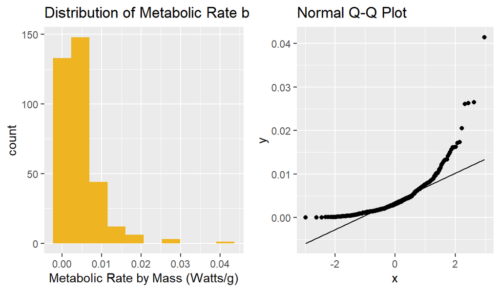

Figure 1: Histogram and Normal Q-Q plot of Metabolic Rate by Mass.

The distribution of Metabolic Rate is right-skewed – lower values occur with higher frequency – and a potential for outliers. We can see the skew in the Normal Q-Q plot as well from the curve of the points from the line.

### Longevity EDA

We plot the same graphs for Longevity in Figure 2 below.

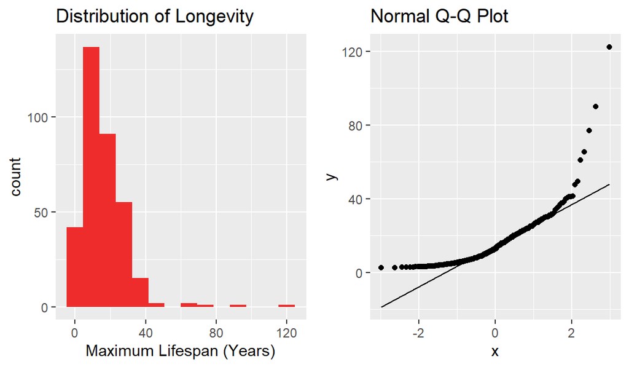

Figure 2: Histogram and Normal Q-Q plot of Longevity.

### Multivariate EDA

We plot both variables against each other in the scatterplot shown below (Figure 3).

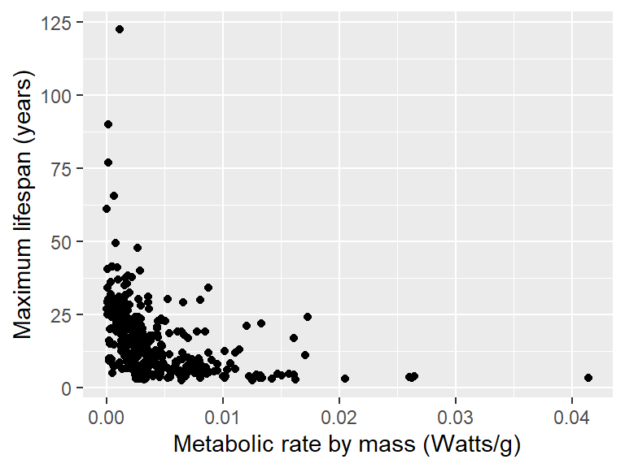

We observe that the overall trend between Metabolic Rate and Longevity appears to be negatively associated; lower Metabolic Rates are associated with higher Longevity. (6)

A linear model relating Longevity from Metabolic Rate yields an adjusted R-squared of 0.1459, i.e. about 14.6% of the variation in the data points is explained by our linear model– this is fairly low. The correlation between Metabolism and Longevity is about -0.385. We can conduct a Pearson’s product-moment correlation test to reach the conclusion that this is not an insignificant correlation coefficient, but it can be improved through a transformation. Since both Metabolism and Longevity are right-skewed, we find that a (natural) logarithmic transformation relating the log of Longevity to the log of Metabolism will result more normal distributions for both variables (Figure 4) and thus a better linear model. (4)

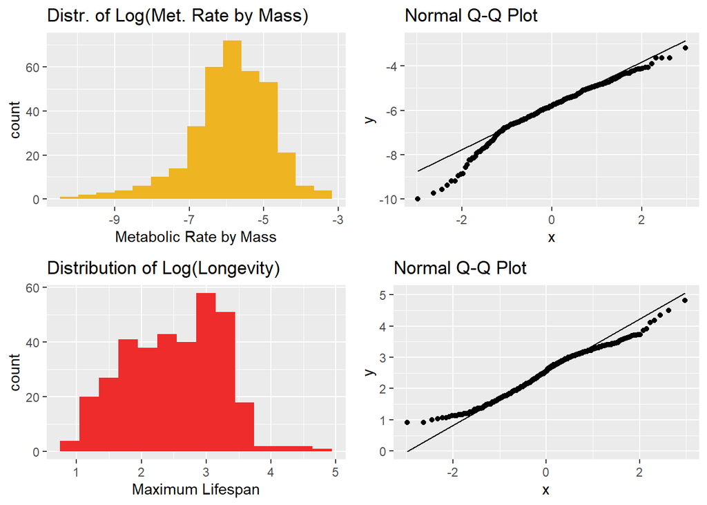

Figure 4: Histograms and Normal Q-Q plots of the log-transformed variables.

We can see that the histograms and Q-Q plots appear to adhere better to normality after the transformation. (5)

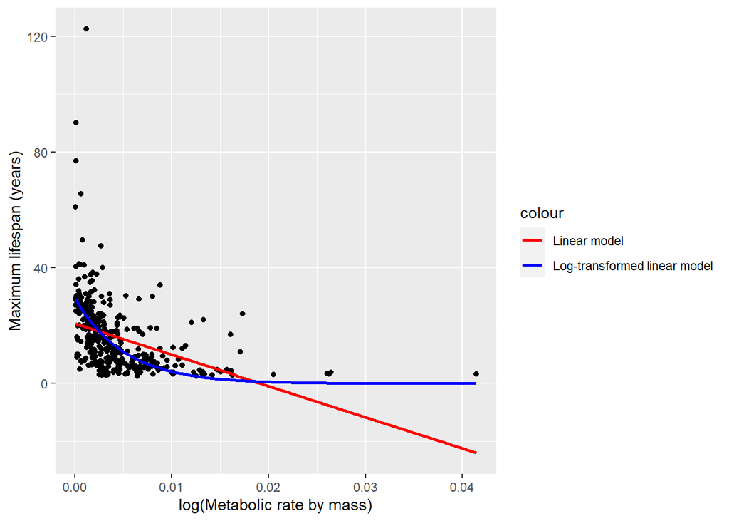

Figure 5: The linear models overlaid on the scatterplot.

# Modeling & Diagnostics

We first construct a linear model of the form

$$\text{ln(Longevity)} \sim \beta_0 +
\beta_1 \text{ln(MetabolicRate)}$$
The resulting model has a $\beta_0 = 0.1492$ and $\beta_1 = -0.3999$, the latter with a p-value of 2.2e-16, so we can conclude it is significant.

Out of a desire to try fitting a more complex model, we also construct a natural cubic spline of made up of piecewise polynomials with the number of knots depending on its degrees of freedom (df). We use a five-fold cross validation to measure the mean squared error and find the resulting MSEs for df values between 3 and 7, shown in Table 1.

df vs. MSE

| df | MSE |
| --- | --- |
| 3 | 129.4169 |
| 4 | 124.0357 |
| 5 | 122.1165 |
| 6 | 121.8325 |
| 7 | 122.1691 |

According this particular cross-validation, the degree of freedom that yields the lowest mean error is 6, which is the df of the spline model we will follow through with. We also attempted fitting a spline model to the log-transformed data, but this yielded a lowest MSE of 401.2455 and so will not be considered.

## Linear versus Spline Model Comparison

The MSE and standard errors (SE) of each model are displayed in Table 2 below. Note that since our linear model was $\ln(y) \sim \ln(x)$, we raise $e$ to the power of the predicted values from the linear model while calculating residuals in order to compare the linear model’s metrics to the spline model’s, which were obtained without a log-transformation.

Model vs. MSE and SE

| Model | MSE | SE |
| --- | --- | --- |
| Linear | 129.4377 | 11.41000 |
| Spline | 117.2832 | 40.73935 |

The MSE of the spline model is lower than that of the linear model, but the standard error of the linear model is less than that of the spline. Since the difference between the MSEs is not very large (about 12.1545) compared to the difference between SEs, it could be possible for a different set of cross-validation folds to result in a higher MSE for the spline model. (5) We also prefer simpler models by Occam’s Razor and to avoid overfitting, so we will be moving forward with the linear model.

We can plot both models over the scatterplot of the two variables to see how the two compare (Figure 6).

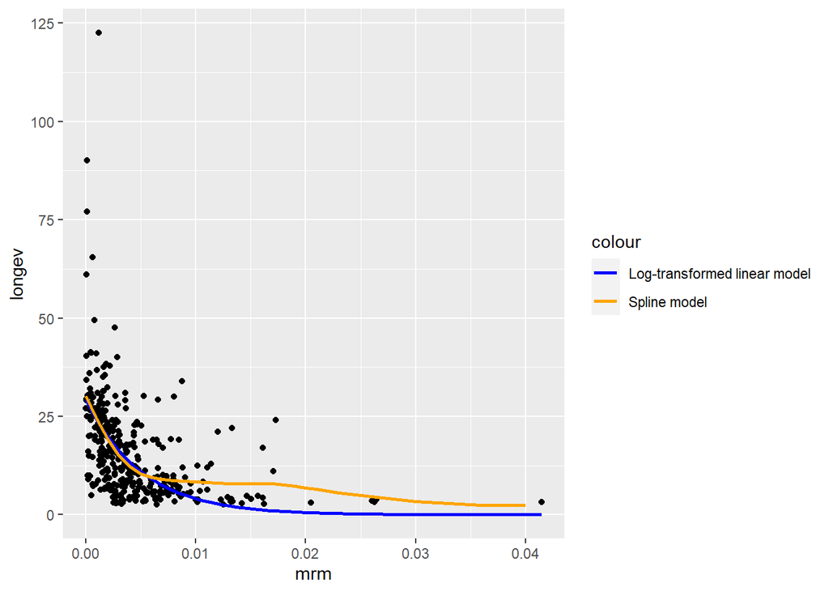

Figure 6: The linear model and spline model overlaid over the scatterplot.

## Linear Model Diagnostics

We check if the linear model adheres to the Simple Linear Regression assumptions of linearity, constant variance, independence, and normality with the Residuals and Normal Q-Q plots (Figure 7).

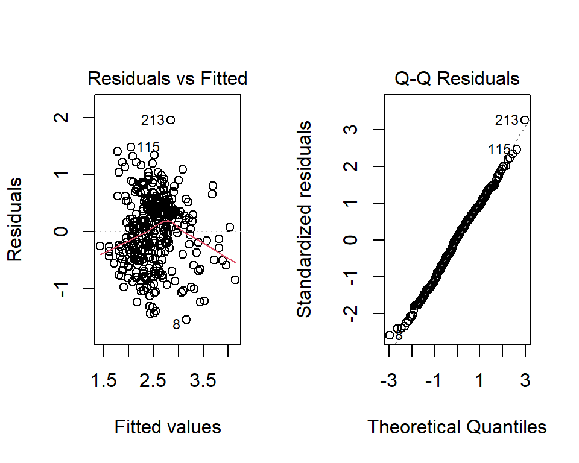

Figure 7: Residuals and Normal Q-Q plot for the linear model.

The Residuals plot appears to show a relationship between residuals and fitted values, but not very egregiously and the residuals appear mostly normally distributed and centered around zero. The points of the Q-Q plot appear very close to the straight line. From these diagnostic plots we can conclude that the model adheres to the SLR assumptions. (4)

To find the 95% confidence interval of our predicted value, we use a pivotal confidence interval by performing 1000 bootstrap iterations. In this case, since the model diagnostics showed that the model adheres quite well to SLR assumptions, we use a fully parametric bootstrap to calculate the uncertainty of a specific prediction value. (6)

# Results

By viewing Figure 6, we can see that the association between metabolic rate and lifespan is negative: lower metabolic rates do indeed have longer lifespans.

We wish to predict the longevity of a crab-eating raccoon (HAGRID = 1898) with a 50% reduced metabolic rate using this model. A crab-eating raccoon’s metabolic rate by mass is about 0.0022, and its 50% reduced metabolic rater by mass is about 0.0011. With our model, we find that the predicted lifespan for this metabolic rate is about 2.8681 ln(years), or about 17.6 years. This prediction is lower than the actual maximum lifespan of a crab-eating raccoon, 19 years, but greater than the model’s predicted lifespan for an animal with the unmodified metabolism of the raccoon, 13.3 years. (Note that the model’s predicted lifespan being less than the actual lifespan occurs with the spline model as well, with the spline model predicting 18.2 years, so this is not necessarily indicative of model performance.) We can instead say that the model yielded a 32.33% increase in predicted lifespan on average for an animal with the lifespan of these characteristics.

We use the 1000 bootstrap samples to obtain that many estimates of the the predicted value and first perform a Shapiro-Wilk test to test the null hypothesis that the bootstrap estimates are normal, which is an assumption of the t-test, which we use to find the 95% confidence interval. The Shapiro-Wilk test resulted in a p-value of 0.5536, which is large enough to not reject that the estimate are normally distributed. The t-test of comparing the mean of the bootstrap samples to the linear model’s predicted value yielded a p-value of 0.1588, meaning we do not reject the null hypothesis that the true mean (of the bootstrap samples of the estimate) is equal to the model’s prediction. The 95% confidence interval obtained from the t-test is $[2.86733, 2.872804]$ ln(years), which is equal to an interval of $[17.58999, 17.68654]$ years or a percent increase of $[32.25557\%, 32.98152\%]$ in lifespan from a metabolic rate reduction of 50%.

# Conclusions

This study ultimately determined that the relationship between metabolic rate and lifespan was that the two were negatively associated, so a lower metabolic rate results in a higher lifespan. Between a linear model and a spline model, we concluded that the variables would be best modeled with a log-transformed linear regression model. Using this model, we found that an animal with the metabolic rate of a crab-eating raccoon reduced by 50% would have an estimated lifespan increase of between 32.26% and 32.98% on average.

Limitations to this analysis is that since both the response and predictor variable were log-transformed, the naive back-transformation of the variables to compute the confidence interval may not have been appropriate. Additionally, the data of about 300 animals contained a number of non-mammals (32 of them, to be exact), and a more accurate model for estimating the lifespan for mammalian humans could be found by using a larger dataset of mammals exclusively. Fitting a multivariate regression may also have yielded a more sophisticated model.